# Uncertainty in bootstrapping

Seth Caldwell

2022-09-07

## Biomasse and NDVI in Chad

During the development of the observational triggers in Chad, analysis was done to compare the performance of biomasse and NDVI (along with other variables) in predicting drought.

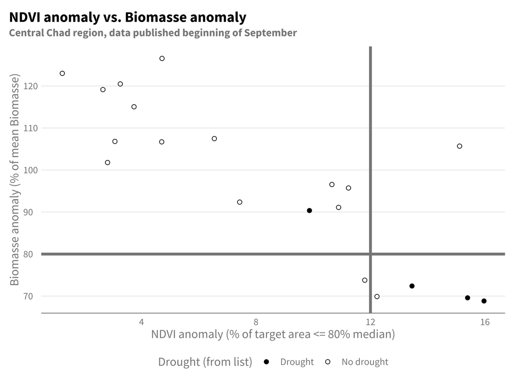

Much of this analysis centered around the setting of thresholds and then comparison of performance metrics. Above, we can see a threshold of 12% of the total area with anomalous NDVI (the vertical bar), and a horizontal bar of cumulative biomasse being <= 80%. The dots represent observed years and respective NDVI and biomasse values in those years.

While biomasse performed better than NDVI in general statistics, one of the other things noticed about biomasse was that it appeared to have larger margins surrounding the points, meaning that the threshold was better able to separate the data and potentially less likely to overfit and suffer from high uncertainty.

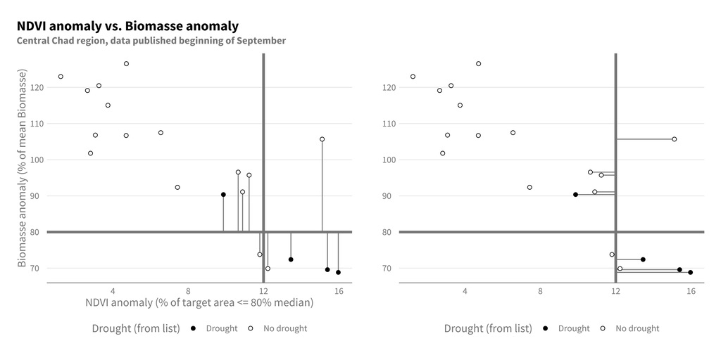

However, we lacked a test dataset that could better show the performance of any model on data it hasn’t trained on, and we didn’t have time to explore further. Here I explore a potential option that could be used to assess this uncertainty when we calculate bootstrap performance.

## Standard deviation

The idea is to simply use the standard deviation of the observed points to estimate the uncertainty in our threshold.

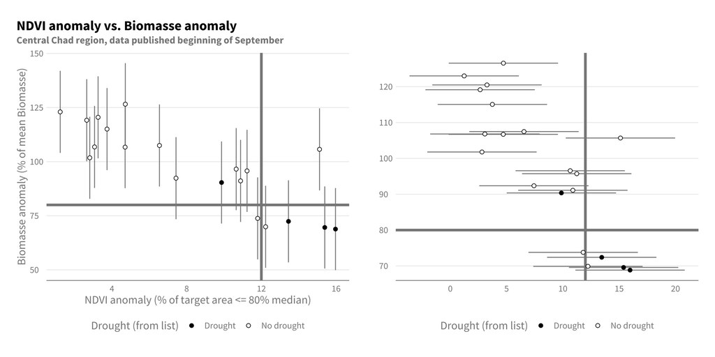

However, we don’t want to just look at overlap of points and their standard deviation with the potential threshold.

## Bootstrapping

What we can do is bootstrap the points with replacement, but alongside that bootstrap also jitter the points to estimate our uncertainty by to each point randomly jittering with a normally distributed value around 0 and the observed standard deviation, then recalculate our predictions and performance metrics.

This might provide a more realistic point estimate of our performance metrics as well as distribution that can be used to compare and select between different data sources and also present a more realistic picture in our model cards.

## Results

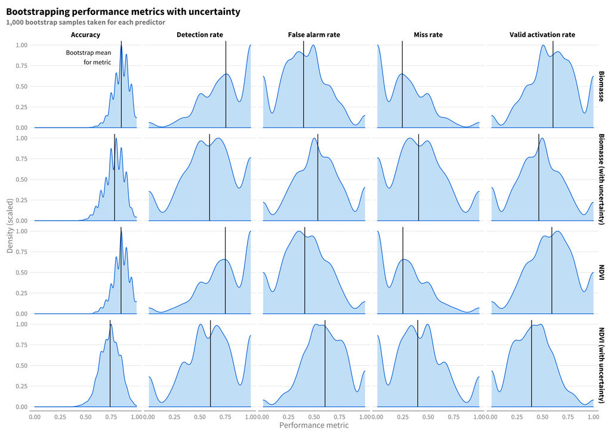

Above, we can see that there is a significant drop in performance across various metrics using this approach, for both NDVI and biomasse. However, it’s hard to compare overall using the above plots.

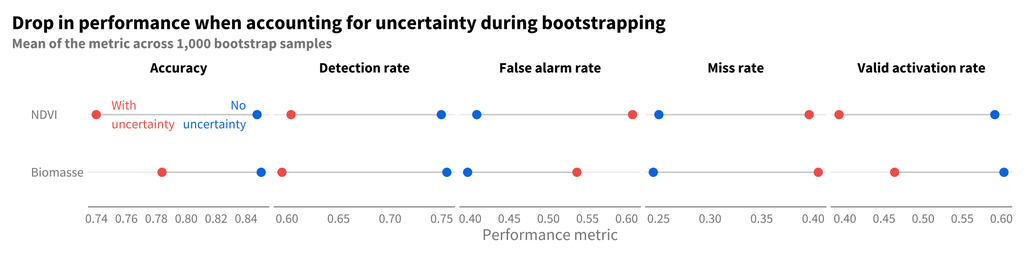

Now, above, we can see that while there are drops in performance from the blue (bootstrapping without uncertainty) and red (bootstrapping with uncertainty), this drop is less significant for biomasse compared to NDVI, particularly in its accuracy, false alarm rate, and valid activation rate, while both have nearly identical performance in detection/miss rates.

From this, we might agree with our original conclusion that the separation of the biomasse threshold (similar to how we evaluate SVM performance) is better than NDVI and more robust to the uncertainty inherent in the data and our setting of the threshold.